# 第1回 補足資料

Higashiguchi Rinhi

2024-10-10

データは[ここから](https://github.com/Higashiguchi-Rinhi/tokushujikken/blob/a6c79de622c7c14cf7dca3f13389a0684a50746b/dataset/five_subject_score_n20p5.csv)ダウンロードしてください。

# 1 動作確認

```r
library(psych)
library(GPArotation)
data = read.csv("ダウンロードしたcsvファイル")
res = fa(data, nfactors=2, fm="ml", rotate="geominQ")
print(res$loadings)
```

```
Loadings:
         ML2    ML1
Japanese  0.598  0.223
English   0.777
Society   0.688 -0.149
Math      0.282  0.515
Science          0.923

                 ML2   ML1
SS loadings    1.515 1.190
Proportion Var 0.303 0.238
Cumulative Var 0.303 0.541
```

# 2 課題

## 2.1 参加者数$N$及び観測変数の数$J$を求めよ

**Click for 1a) and b) Answer**

```r
N=nrow(data) #1a)
J=ncol(data) #1b)
cat(paste0("答え:参加者数は", N, ", ", "観測変数の数は",J))
```

```
答え:参加者数は20, 観測変数の数は5
```

## 2.2 潜在変数$K$の数および解釈について

**Click for 2a) Answer**

`nfactors=` で潜在変数を設定する。答えは2。

**Click for 2b) Answer**

文系科目(Japanese, English, Society)と理系科目(Math, Science)と考えられる。

また、文系科目と理系科目は該当する因子への因子負荷量が$0.5$以上である。

```
Loadings:
         ML2    ML1
Japanese  0.598  0.223
English   0.777
Society   0.688 -0.149
Math      0.282  0.515
Science          0.923

                 ML2   ML1
SS loadings    1.515 1.190
Proportion Var 0.303 0.238
Cumulative Var 0.303 0.541
```

# 3 おまけ: データの保存について

😥毎回Rを開くとそれまでのデータが消えてしまう…!

## 3.1 Workspaceでの保存

以下の写真の部分。 セーブボタンから保存し、次回そのセーブしたWorkspaceを📂ボタンからロードするだけで今回の分析のまま変数とかが読み込まれる。

### 3.1.1 保存

[figure not shown]

### 3.1.2 読み込み

[figure not shown]

## 3.2 rds形式での保存

多くの場合Workspace全体ではなく、分析の結果(この場合`res`)のみを保存したい。

もちろんcsvファイルなどで保存するのも良いがRではオブジェクトをそのまま保存するデータ形式がある。 それがこのrds形式である。 今私のWorkspaceには以下のようなDataが入っている。

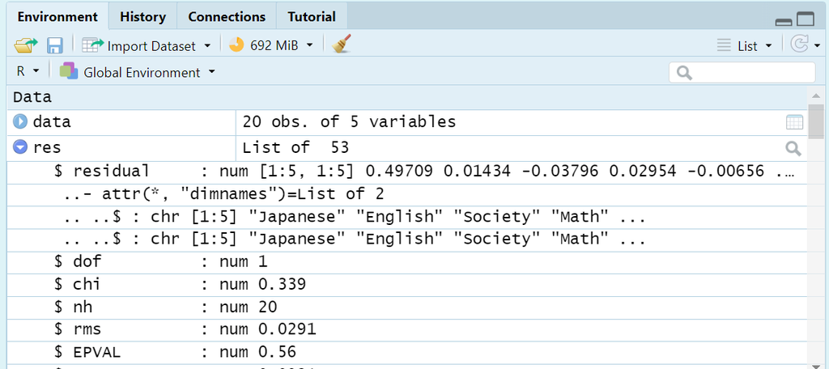

`res`の下に`$residual`や`$dof`といったものが多数あるのが確認できる。

`res$loadings`で読み込んだのは`res`に格納されていた`loadings`というデータ(厳密には用語が違うかも)だということです。csvで保存する場合は`loadings`など一部を保存することになると思うのですが、`.rds`形式で保存するとそのまま保存&読み込みができます。

### 3.2.1 保存

```r
saveRDS(res, file="ファイル名.rds")
```

注: このとき拡張子`.rds`を忘れずに

### 3.2.2 読み込み

```r
res = readRDS(file="ファイル名.rds")
```

もちろん他の変数名として読みこむことも可能

```r
# geomin回転で分析したで因子分析の結果という意味で
geomin_res = readRDS(file="ファイル名.rds")
```

以上です。一旦R Studioを閉じてみて読み込みをしてみてください。

以下をコンソールに打ち込めば閉じます。

```r
q()
```